# WST Pop Model: Mortality

### Background

Most important, I want to understand how S. Blackburn (Univ. of Idaho; SB) took raw CDFW data, and then created dataframes (or other data types) to ‘feed’ the model. This is an important first-step towards understanding the model. Herein I explore how SB estimated rates of survival, mortality, and instantaneous rates (J. DuBois, 09-Feb-2018; see original SB file `mortality.txt`).

SB used Chapman-Robson estimator with peak plus one criterion to estimate S (survival) and Z (instantaneous total mortality). SB sourced code from Ogle 2016.

SB used the R libraries below.  
- library(FSA)  
- library(car)  
- library(dplyr)  
- library(magrittr)  
- library(Rcapture)

```r
library(FSA)
library(car)
library(dplyr)
library(magrittr)
# library(Rcapture)
```

### Data

SB creates a dataframe called `all` with `age` & `ct` (presumably short for catch) fields. Catch data in `all` (herein named `catch_at_age`) have NOT been adjusted for trammel net (gear) selectivity.

Ages (`age`) in `catch_at_age` are from 3 to 19. Catch (`ct`) is presumably count at each age from CDFW 2014-2016 trammel data. *Was an AL key was used to get ages or were these fish directly aged through finrays?*

```r
# create dataframe (renamed from all)
catch_at_age <- data.frame(
  age = 3:19,
  ct = c(
    33, 38, 80, 111, 158, 179, 132, 68,
    46, 25, 48, 24, 35, 2, 20, 3, 4
  )
)
```

SB plots `log(ct) ~ age` to look at peak catch (age 8 for these data). The resulting plot is a catch curve (below).

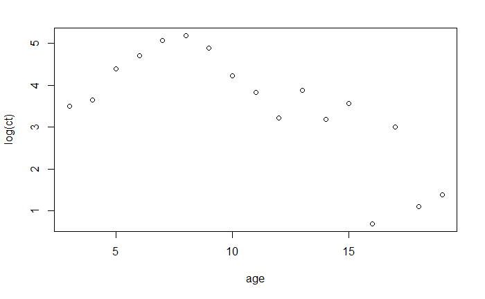

```r
plot(log(ct) ~ age, data = catch_at_age)
```

### Employ Chapman-Robson

Using `chapmanRobson()` in package `FSA`, SB creates and plots variable `thr`. We confirm (through arithmetic) `chapmanRobson()` returns values according to Ricker eqn 2.5 (pg. 31; S) and Ricker eqn page 29 (Z). The ‘peak plus one’ method assigns N<sub>0</sub> (starting age) to the peak age + 1, in this case age 9.

For comparison, SB re-runs (not shown here) `chapmanRobson()` using all ages (3-19). As SB states, this is *not* peak plus one and violates assumption of CR estimator.

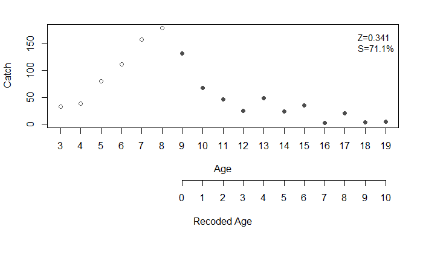

```r
thr <- chapmanRobson(ct ~ age, data = catch_at_age, ages2use = 9:19)
plot(thr)
```

#### Catch Curve

Using `catchCurve()` in package `FSA`, SB creates and plots variable `thcc`. SB states this “violates assumption of constant recruitment” and advises not to use. Reruns `catchCurve()` setting `use.weights` argument to `TRUE`, but this does not seem to change much, if at all.

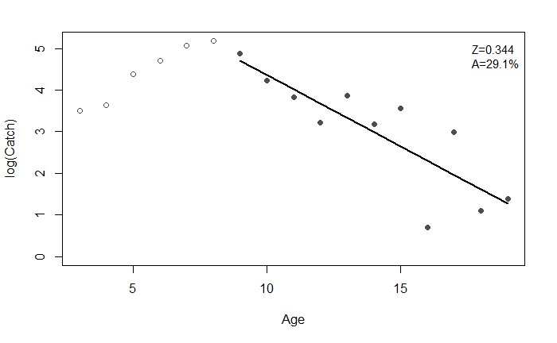

```r
thcc <- catchCurve(ct ~ age, data = catch_at_age, ages2use = 9:19)
plot(thcc)
```

### Data (corrected)

In this section, SB adjusts catch data for trammel net (gear) selectivity. SB creates a similar dataframe (as `catch_at_age`; SB called this dataframe `select`) only `ct` appears to be adjusted. But how SB corrected for gear selectivity is not clear.

```r
# create dataframe (renamed from select; _c = corrected)
catch_at_age_c <- data.frame(
  age = 3:19,
  ct = c(
    45, 53, 128, 122, 164, 181, 136, 72,
    52, 34, 92, 55, 105, 7, 91, 21, 66
  )
)
```

and again plotting…peak still at age 8.

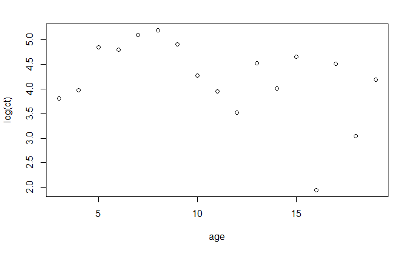

```r
plot(log(ct) ~ age, data = catch_at_age_c)
```

and again employing `chapmanRobson()`…this time setting `"Hoenigetal"` to the argument `zmethod` to (presumably) correct for overdispersion as SB states. Results are similar to running on non-adjusted data, but S does increase by about 10%. Not sure if `"Hoenigetal"` made a difference.

SB also reruns (not shown here) `catchCurve()` on adjusted catch data.

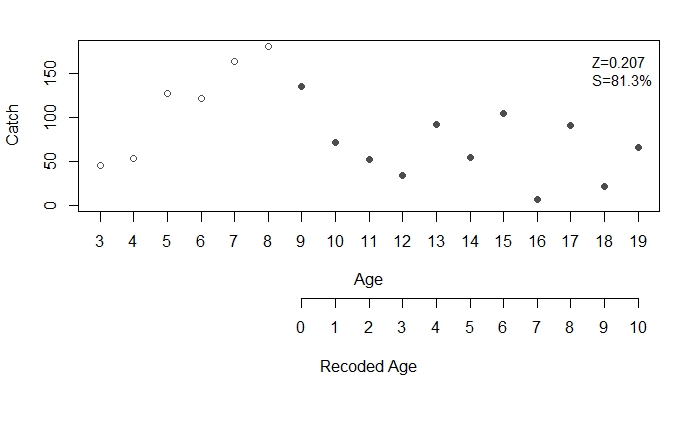

```r
thr2 <- chapmanRobson(
  ct ~ age,
  data = catch_at_age_c,
  zmethod = "Hoenigetal",
  ages2use = 9:19
)
plot(thr2)
```

### Estimates of M

Instantaneous natural mortality (M) is “highly correlated with various life histories and abiotic factors” - SB. SB uses `metaM()` to estimate M as an alternative approach to Chapman-Robson or catch curves.

```r
Linf <- 381.12 # not sure where SB got this value
K <- 0.027234  # not sure where SB got this value
Temp <- 15.96  # average water temp in Suisun Bay
tmax <- 50     # max age of the stock
FSA::metaM(method = "PaulyL", Linf = Linf, K = K, Temp = Temp)
```

```
'Linf' value seems unreasonable.  Make sure value is in centimeters.
```

```
[1] 0.06410068
```

getting warning `Linf` “value seems unreasonable” and to make sure it’s in centimeters.

or…

```r
FSA::metaM(
  method = c("PaulyL", "HoenigOF", "tmax", "PaulyLNoT"),
  Linf = Linf,
  K = K,
  Temp = Temp,
  tmax = tmax
)
```

```
'Linf' value seems unreasonable.  Make sure value is in centimeters.'Linf' value seems unreasonable.  Make sure value is in centimeters.
```

| method | M |
| --- | --- |
| PaulyL | 0.06410068 |
| HoenigOF | 0.08281524 |
| tmax1 | 0.10218000 |
| PaulyLNoT | 0.04174143 |

### Questions

1. Was an AL key was used to get ages or were all these fish directly aged through finrays? *age-length key used from fish aged collected in CDFW survey (n=374 used in ALKEY)*
2. How did SB correct for gear (trammel net) selectivity?  
   *Millar and Fryer 1999 - Select Method 34 different length categories*
3. How does `"Hoenigetal"` correct for overdispersion?  
   *not sure, following what other studies had done*
4. How were `Linf` and `K` derived? Obviously from VBGM but using what data? *back-calculated length at age CDFW data; Dahl-le method*
5. Can we derive $M$ from `chapmanRobson()` results? Yes, I believe using $M = Z - F$, but we’ll need $\mu$.  
   *yes, need exploitation, using CRobson is better route*
6. Raw data used to get `ct` (catch)? CDFW 2014-2016?  
   *yes*
7. Ultimately, Chapman-Robson Peak+1 was used to estimate $Z$ and $S$, correct? What about $M$?  
   *correct for M you need exploitation*

return to top

run: 2018-02-27 13:18:05  
CDFW, Sportfish